# NYC Taxi

## Introduction

The are two main objectives in this notebook:

- To explore the data offered by NYC about trips taken by NYC taxis
- To develop a model that can predict the tip amount.

The data used in this notebook have been downloaded from [here](http://www.nyc.gov/html/tlc/html/about/trip_record_data.shtml) using March, June and November. Documentation about this data can be found [here](http://www.nyc.gov/html/tlc/downloads/pdf/data_dictionary_trip_records_yellow.pdf).

## 1. EDA (Exploratory Data Analysis)

### 1.1 Load and check data

```python
%matplotlib inline
import pandas as pd
import matplotlib.pyplot as plt
import numpy as np
import seaborn as sns
from sklearn.model_selection import train_test_split
import xgboost as xgb
import warnings
from sklearn.linear_model import LinearRegression, Ridge,BayesianRidge
from sklearn.cluster import MiniBatchKMeans
from sklearn.metrics import mean_squared_error
from sklearn.metrics import accuracy_score
from sklearn.model_selection import KFold
from sklearn.model_selection import cross_val_score
```

```python
pd.set_option('display.float_format', lambda x: '%.3f' % x)
warnings.simplefilter('ignore')
```

```python
!ls data
```

```
yellow_tripdata_2017-03.csv yellow_tripdata_2017-11.csv
yellow_tripdata_2017-06.csv
```

```python
taxi_march_2017 = pd.read_csv('data/yellow_tripdata_2017-03.csv')
taxi_june_2017 = pd.read_csv('data/yellow_tripdata_2017-06.csv')
taxi_november_2017 = pd.read_csv('data/yellow_tripdata_2017-11.csv')
```

```python
taxi_march_2017.head()
```

|  | VendorID | tpep_pickup_datetime | tpep_dropoff_datetime | passenger_count | trip_distance | RatecodeID | store_and_fwd_flag | PULocationID | DOLocationID | payment_type | fare_amount | extra | mta_tax | tip_amount | tolls_amount | improvement_surcharge | total_amount |
| --- | --- | --- | --- | --- | --- | --- | --- | --- | --- | --- | --- | --- | --- | --- | --- | --- | --- |
| 0 | 2 | 2017-03-09 21:30:11 | 2017-03-09 21:44:20 | 1 | 4.060 | 1 | N | 148 | 48 | 1 | 14.000 | 0.500 | 0.500 | 3.060 | 0.000 | 0.300 | 18.360 |
| 1 | 2 | 2017-03-09 21:47:00 | 2017-03-09 21:58:01 | 1 | 2.730 | 1 | N | 48 | 107 | 2 | 11.500 | 0.500 | 0.500 | 0.000 | 0.000 | 0.300 | 12.800 |
| 2 | 2 | 2017-03-09 22:01:08 | 2017-03-09 22:11:16 | 1 | 2.270 | 1 | N | 79 | 162 | 1 | 10.000 | 0.500 | 0.500 | 2.820 | 0.000 | 0.300 | 14.120 |
| 3 | 2 | 2017-03-09 22:16:05 | 2017-03-10 06:26:11 | 1 | 3.860 | 1 | N | 237 | 41 | 1 | 12.000 | 0.500 | 0.500 | 3.990 | 0.000 | 0.300 | 17.290 |
| 4 | 2 | 2017-03-31 06:31:53 | 2017-03-31 06:41:48 | 1 | 3.450 | 1 | N | 41 | 162 | 2 | 12.000 | 0.500 | 0.500 | 0.000 | 0.000 | 0.300 | 13.300 |

```python
taxi_june_2017.head()
```

|  | VendorID | tpep_pickup_datetime | tpep_dropoff_datetime | passenger_count | trip_distance | RatecodeID | store_and_fwd_flag | PULocationID | DOLocationID | payment_type | fare_amount | extra | mta_tax | tip_amount | tolls_amount | improvement_surcharge | total_amount |
| --- | --- | --- | --- | --- | --- | --- | --- | --- | --- | --- | --- | --- | --- | --- | --- | --- | --- |
| 0 | 2 | 2017-06-08 07:52:31 | 2017-06-08 08:01:32 | 6 | 1.030 | 1 | N | 161 | 140 | 1 | 7.500 | 1.000 | 0.500 | 1.860 | 0.000 | 0.300 | 11.160 |
| 1 | 2 | 2017-06-08 08:08:18 | 2017-06-08 08:14:00 | 6 | 1.030 | 1 | N | 162 | 233 | 1 | 6.000 | 1.000 | 0.500 | 2.340 | 0.000 | 0.300 | 10.140 |
| 2 | 2 | 2017-06-08 08:16:49 | 2017-06-08 15:43:22 | 6 | 5.630 | 1 | N | 137 | 41 | 2 | 21.500 | 1.000 | 0.500 | 0.000 | 0.000 | 0.300 | 23.300 |
| 3 | 2 | 2017-06-29 15:52:35 | 2017-06-29 16:03:27 | 6 | 1.430 | 1 | N | 142 | 48 | 1 | 8.500 | 1.000 | 0.500 | 0.880 | 0.000 | 0.300 | 11.180 |
| 4 | 1 | 2017-06-01 00:00:00 | 2017-06-01 00:03:43 | 1 | 0.600 | 1 | N | 140 | 141 | 1 | 4.500 | 0.500 | 0.500 | 2.000 | 0.000 | 0.300 | 7.800 |

```python
taxi_november_2017.head()
```

|  | VendorID | tpep_pickup_datetime | tpep_dropoff_datetime | passenger_count | trip_distance | RatecodeID | store_and_fwd_flag | PULocationID | DOLocationID | payment_type | fare_amount | extra | mta_tax | tip_amount | tolls_amount | improvement_surcharge | total_amount |
| --- | --- | --- | --- | --- | --- | --- | --- | --- | --- | --- | --- | --- | --- | --- | --- | --- | --- |
| 0 | 1 | 2017-11-01 00:01:48 | 2017-11-01 00:03:47 | 1 | 0.400 | 1 | N | 151 | 151 | 2 | 3.500 | 0.500 | 0.500 | 0.000 | 0.000 | 0.300 | 4.800 |
| 1 | 1 | 2017-11-01 00:18:22 | 2017-11-01 00:40:32 | 1 | 4.800 | 1 | N | 142 | 144 | 1 | 17.500 | 0.500 | 0.500 | 2.000 | 0.000 | 0.300 | 20.800 |
| 2 | 1 | 2017-11-01 00:01:58 | 2017-11-01 00:15:57 | 1 | 3.700 | 1 | N | 151 | 140 | 1 | 14.000 | 0.500 | 0.500 | 3.050 | 0.000 | 0.300 | 18.350 |
| 3 | 1 | 2017-11-01 00:18:53 | 2017-11-01 00:25:23 | 1 | 1.900 | 1 | N | 140 | 233 | 1 | 7.500 | 0.500 | 0.500 | 1.320 | 0.000 | 0.300 | 10.120 |
| 4 | 1 | 2017-11-01 00:28:56 | 2017-11-01 00:38:22 | 1 | 2.000 | 1 | N | 229 | 50 | 1 | 9.000 | 0.500 | 0.500 | 2.000 | 0.000 | 0.300 | 12.300 |

```python
if len(taxi_march_2017.columns.intersection(taxi_june_2017.columns) == 0) and len(taxi_march_2017.columns.intersection(taxi_november_2017.columns) == 0) and len(taxi_june_2017.columns.intersection(taxi_november_2017.columns) == 0):
    print('All datasets have the same columns')
```

```
All datasets have the same columns
```

March, June and November have the same columns so, in order to explore the data easier I concatenate the three datasets in only one.

```python
df_taxi = pd.concat([taxi_march_2017, taxi_june_2017, taxi_november_2017])
```

```python
df_taxi.info()
```

```
<class 'pandas.core.frame.DataFrame'>
Int64Index: 29236424 entries, 0 to 9284802
Data columns (total 17 columns):
VendorID                 int64
tpep_pickup_datetime     object
tpep_dropoff_datetime    object
passenger_count          int64
trip_distance            float64
RatecodeID               int64
store_and_fwd_flag       object
PULocationID             int64
DOLocationID             int64
payment_type             int64
fare_amount              float64
extra                    float64
mta_tax                  float64
tip_amount               float64
tolls_amount             float64
improvement_surcharge    float64
total_amount             float64
dtypes: float64(8), int64(6), object(3)
memory usage: 3.9+ GB
```

There are some columns that their type cannot be guessed by Pandas. Later, these columns should be transformed to a different type.

```python
df_taxi.describe()
```

|  | VendorID | passenger_count | trip_distance | RatecodeID | PULocationID | DOLocationID | payment_type | fare_amount | extra | mta_tax | tip_amount | tolls_amount | improvement_surcharge | total_amount |
| --- | --- | --- | --- | --- | --- | --- | --- | --- | --- | --- | --- | --- | --- | --- |
| count | 29236424.000 | 29236424.000 | 29236424.000 | 29236424.000 | 29236424.000 | 29236424.000 | 29236424.000 | 29236424.000 | 29236424.000 | 29236424.000 | 29236424.000 | 29236424.000 | 29236424.000 | 29236424.000 |
| mean | 1.546 | 1.618 | 2.919 | 1.043 | 163.202 | 161.191 | 1.329 | 13.109 | 0.334 | 0.497 | 1.874 | 0.329 | 0.300 | 16.447 |
| std | 0.498 | 1.261 | 4.477 | 0.510 | 66.614 | 70.478 | 0.490 | 147.282 | 0.462 | 0.071 | 2.646 | 1.969 | 0.014 | 147.525 |
| min | 1.000 | 0.000 | 0.000 | 1.000 | 1.000 | 1.000 | 1.000 | -550.000 | -53.710 | -0.500 | -112.000 | -17.500 | -0.300 | -550.300 |
| 25% | 1.000 | 1.000 | 0.970 | 1.000 | 114.000 | 107.000 | 1.000 | 6.500 | 0.000 | 0.500 | 0.000 | 0.000 | 0.300 | 8.750 |
| 50% | 2.000 | 1.000 | 1.600 | 1.000 | 162.000 | 162.000 | 1.000 | 9.500 | 0.000 | 0.500 | 1.360 | 0.000 | 0.300 | 11.800 |
| 75% | 2.000 | 2.000 | 3.010 | 1.000 | 233.000 | 233.000 | 2.000 | 14.500 | 0.500 | 0.500 | 2.460 | 0.000 | 0.300 | 17.800 |
| max | 2.000 | 192.000 | 9496.980 | 99.000 | 265.000 | 265.000 | 5.000 | 630461.820 | 69.800 | 140.000 | 450.000 | 1018.950 | 1.000 | 630463.120 |

### 1.2 Data Cleaning

```python
def non_na_percentage(df):
    """Returns the percentage of non NA values"""
    return (100*df[df.columns].count() \
                 / len(df[df.columns])).sort_values()
```

```python
non_na_percentage(df_taxi)
```

```
VendorID                100.000
tolls_amount            100.000
tip_amount              100.000
mta_tax                 100.000
extra                   100.000
fare_amount             100.000
payment_type            100.000
improvement_surcharge   100.000
DOLocationID            100.000
store_and_fwd_flag      100.000
RatecodeID              100.000
trip_distance           100.000
passenger_count         100.000
tpep_dropoff_datetime   100.000
tpep_pickup_datetime    100.000
PULocationID            100.000
total_amount            100.000
dtype: float64
```

It's curious to see a dataset with non NA values.

```python
df_taxi['tpep_pickup_datetime'] = pd.to_datetime(df_taxi['tpep_pickup_datetime'])
df_taxi['tpep_dropoff_datetime'] = pd.to_datetime(df_taxi['tpep_dropoff_datetime'])
```

```python
df_taxi = df_taxi[(df_taxi['extra'] >= 0) &
                      (df_taxi['mta_tax'] >= 0) &
                      (df_taxi['tip_amount'] >= 0) &
                      (df_taxi['tolls_amount'] >= 0) &
                      (df_taxi['improvement_surcharge'] >= 0) &
                      (df_taxi['total_amount'] > 0) &
                      (df_taxi['fare_amount'] >= 0) &
                      (df_taxi['trip_distance'] > 0) &
                      (df_taxi['passenger_count'] > 0) &
                      (df_taxi['passenger_count'] < 10) &
                      (df_taxi['tpep_pickup_datetime'] != df_taxi['tpep_dropoff_datetime'])]

date_mask = df_taxi['tpep_pickup_datetime'].map(lambda x: (x.year == 2017 and (x.month == 3 or x.month == 6 or x.month == 11))) == True
df_taxi = df_taxi[date_mask]
```

The data has negative values and evident outliers (passenger_count) so let's clean this selecting only values that have sense. Moreover, passenger_count has a strange value: 0. This value is also avoided. Also, we should avoid trips with the same date for pickup and dropoff.

The data has dates from months we are not interested in. We should filter the dates.

### 1.3 Feature Engineering

```python
df_taxi['store_and_fwd_flag'] = df_taxi['store_and_fwd_flag'].map({'Y': 1, 'N': 0})
```

```python
df_taxi['trip_duration'] = (df_taxi['tpep_dropoff_datetime'].sub(df_taxi['tpep_pickup_datetime'], axis=0).dt.seconds /60)
```

```python
df_taxi['pickup_month'] = df_taxi['tpep_pickup_datetime'].dt.month
df_taxi['pickup_weekday'] = df_taxi['tpep_pickup_datetime'].dt.weekday
df_taxi['pickup_day'] = df_taxi['tpep_pickup_datetime'].dt.day
df_taxi['pickup_hour'] = df_taxi['tpep_pickup_datetime'].dt.hour
```

```python
df_taxi['dropoff_month'] = df_taxi['tpep_pickup_datetime'].dt.month
df_taxi['dropoff_weekday'] = df_taxi['tpep_pickup_datetime'].dt.weekday
df_taxi['dropoff_day'] = df_taxi['tpep_pickup_datetime'].dt.day
df_taxi['dropoff_hour'] = df_taxi['tpep_pickup_datetime'].dt.hour
```

### 1.4 Data Analysis

```python
def styled_barplot(x, title, special_x_size=8, xticks=None):
    """Plot a barplot with a custom style"""
    plt.figure(figsize=(special_x_size,4))
    ax= sns.barplot(x.index, x.values, alpha=0.8)

    if xticks != None:
        ax.set_xticklabels(xticks)

    plt.ylabel('# of {}'.format(title), fontsize=12)
    plt.xlabel('{}'.format(title), fontsize=12)

    rects = ax.patches
    labels = x.values
    for rect, label in zip(rects, labels):
        height = rect.get_height()
        ax.text(rect.get_x() + rect.get_width()/2, height + 5, label, ha='center', va='bottom')
```

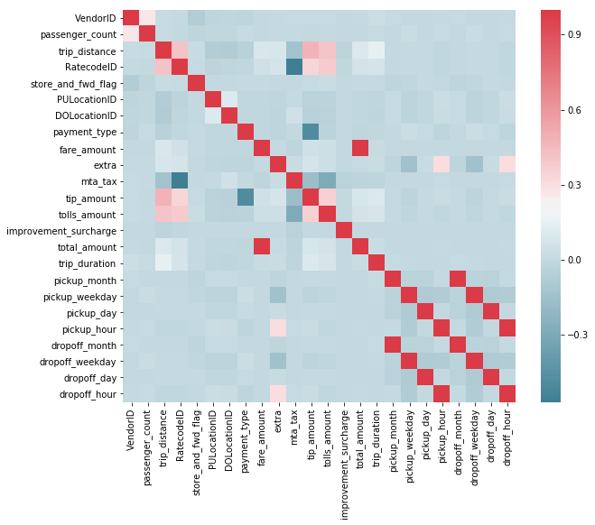

```python
f, ax = plt.subplots(figsize=(10, 8))
corr = df_taxi.corr()
_ = sns.heatmap(corr, mask=np.zeros_like(corr, dtype=np.bool), cmap=sns.diverging_palette(220, 10, as_cmap=True),
            square=True, ax=ax)
```

Some features show high correlation:

- fare_amount and total_amount: this has sense because the higher is the fare amount the higher is the total amount
- The pickup date and the dropoff date have high correlation as expected

If we focus on the target variable (tip_amount) we discover that there are some variables with a interesting correlation: tolls_amount, RatecodeID and trip_distance. This is important for the model developed later.

### 1.4.1 Univariate Analysis

**VendorID**

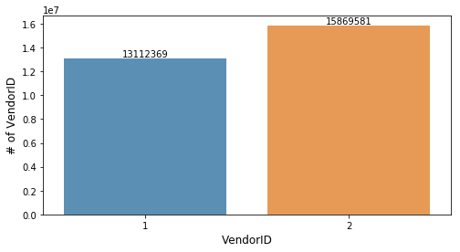

```python
x = df_taxi['VendorID'].value_counts()
x = x.sort_index()
styled_barplot(x, 'VendorID')
```

Vendor two has more success than vendor one (at least in amount of trips)

**passenger_count**

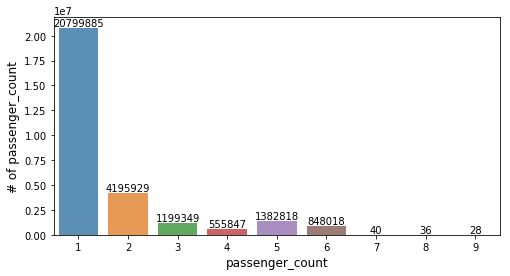

```python
x = df_taxi['passenger_count'].value_counts()
x = x.sort_index()
styled_barplot(x, 'passenger_count')
```

Most trips contain between 1 and 6 passengers. From this chart we can say that people usually travel alone by taxi.

**trip_duration**

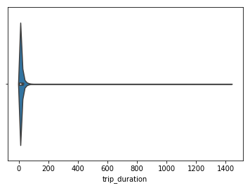

```python
sns.violinplot(x=df_taxi['trip_duration'])
```

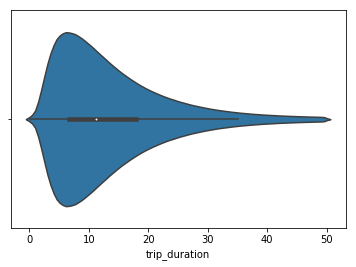

```python
sns.violinplot(x=df_taxi[df_taxi['trip_duration'] < 50]['trip_duration'])
```

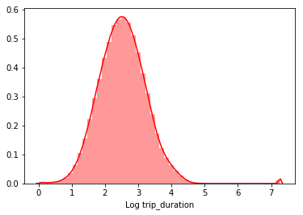

```python
sns.distplot(np.log(df_taxi['trip_duration'].values + 1), axlabel = 'Log trip_duration', label = 'log trip_duration', bins = 50, color="r")
```

No surpises here. Most trips have a duration under 20 minutes.

**trip_distance**

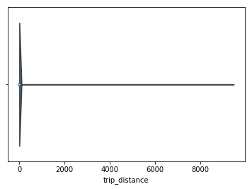

```python
sns.violinplot(x=df_taxi['trip_distance'])
```

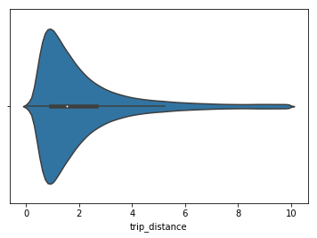

```python
sns.violinplot(x=df_taxi[df_taxi['trip_distance'] < 10]['trip_distance'])
```

It seems that people take a taxi for short distances.

**RatecodeID**

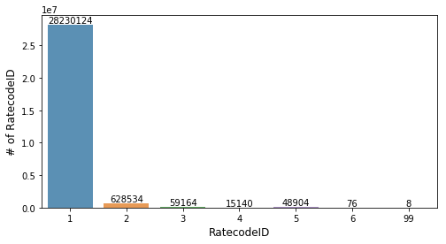

```python
x = df_taxi['RatecodeID'].value_counts()
x = x.sort_index()
styled_barplot(x, 'RatecodeID')
```

**store_and_fwd_flag**

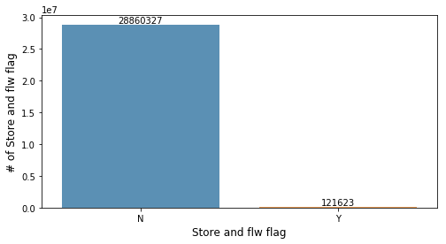

```python
x = df_taxi['store_and_fwd_flag'].value_counts()
x = x.sort_index()
styled_barplot(x, 'Store and flw flag', xticks=['N', 'Y'])
```

**payment_type**

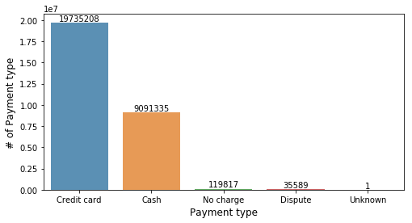

```python
x = df_taxi['payment_type'].value_counts()
x = x.sort_index()
styled_barplot(x, 'Payment type', xticks=['Credit card', 'Cash', 'No charge', 'Dispute', 'Unknown', 'Voided trip'])
```

People prefer to pay by credit card to cash. This is important when developing the model.

**pickup_hour**

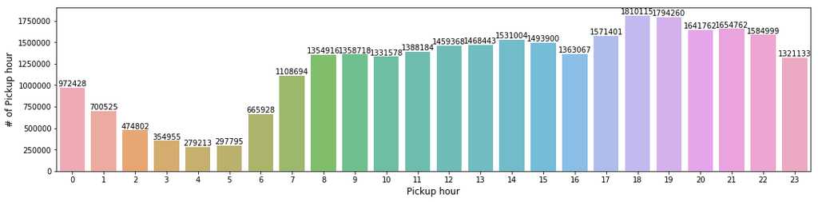

```python
x = df_taxi['pickup_hour'].value_counts()
x = x.sort_index()
styled_barplot(x, 'Pickup hour', special_x_size=18)
```

After midnight the number of pickups decreases as expected. The highest number of pickups are around 6pm-7pm which makes sense because people go home from office.

**pickup_day**

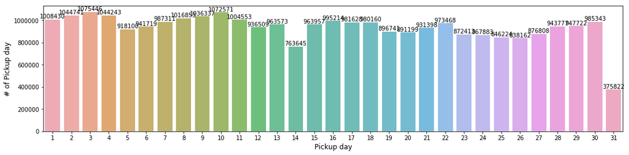

```python
x = df_taxi['pickup_day'].value_counts()
x = x.sort_index()
styled_barplot(x, 'Pickup day', special_x_size=18)
```

November and June have 30 days so it's normal that 31 shows a high fall.

**pickup_weekday**

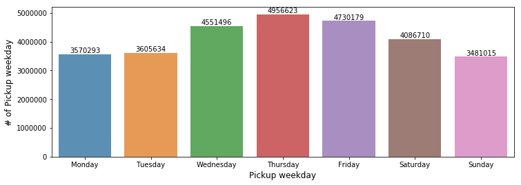

```python
x = df_taxi['pickup_weekday'].value_counts()
x = x.sort_index()
styled_barplot(x, 'Pickup weekday', special_x_size=12,
               xticks=['Monday', 'Tuesday', 'Wednesday', 'Thursday', 'Friday', 'Saturday', 'Sunday'])
```

It's curious how trips are distributed. Maybe, it's normal to think that most trips are in weekend or distributed uniformly from Monday to Friday.

**pickup_month**

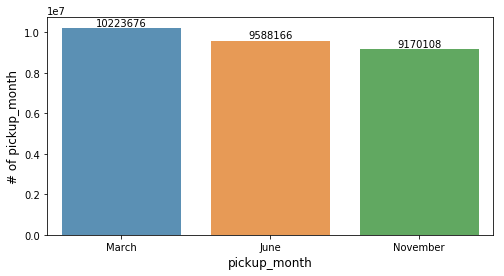

```python
x = df_taxi['pickup_month'].value_counts()
x = x.sort_index()
styled_barplot(x, 'pickup_month', xticks=['March', 'June', 'November'])
```

The trips are distributed uniformly between March, June and November.

**fare_amount**

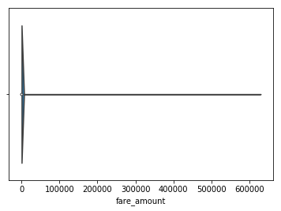

```python
sns.violinplot(x=df_taxi['fare_amount'])
```

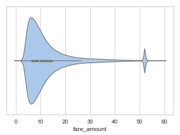

```python
sns.violinplot(x=df_taxi[(df_taxi['fare_amount'] < 60)]['fare_amount'])
```

The fare amount is the time-and-distance fare calculated by the meter. Most trips have a fare amount under 30

**extra**

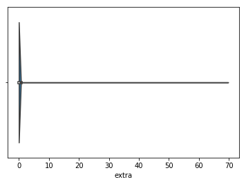

```python
sns.violinplot(x=df_taxi['extra'])
```

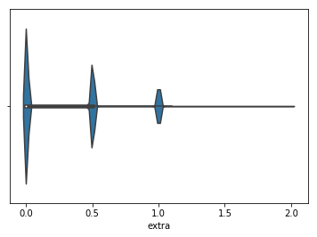

```python
sns.violinplot(x=df_taxi[(df_taxi['extra'] <= 2)]['extra'])
```

**mta_tax**

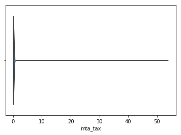

```python
sns.violinplot(x=df_taxi['mta_tax'])
```

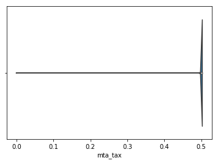

```python
sns.violinplot(x=df_taxi[(df_taxi['mta_tax'] <= 0.5)]['mta_tax'])
```

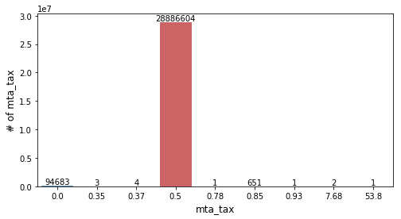

```python
x = df_taxi['mta_tax'].value_counts()
x = x.sort_index()
styled_barplot(x, 'mta_tax')
```

$0.50 MTA tax that is automatically triggered based on the metered rate in use.

**tip_amount**

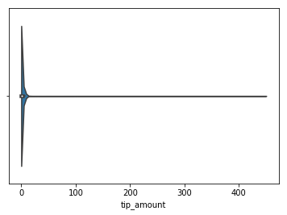

```python
sns.violinplot(x=df_taxi['tip_amount'])
```

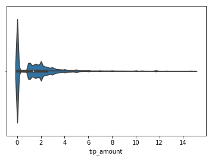

```python
sns.violinplot(x=df_taxi[(df_taxi['tip_amount'] >= 0) & (df_taxi['tip_amount'] <= 15)]['tip_amount'])
```

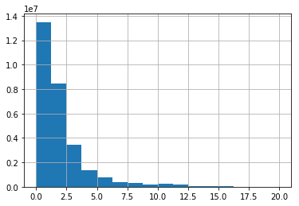

```python
df_taxi[(df_taxi['tip_amount'] < 20)]['tip_amount'].hist(bins=16)
```

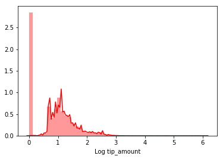

```python
sns.distplot(np.log(df_taxi['tip_amount'].values + 1), axlabel = 'Log tip_amount', label = 'log tip_amount', bins = 50, color="r")
```

Many people don't pay tips when they travel by taxi and those who do pay tips under $6

**tolls_amount**

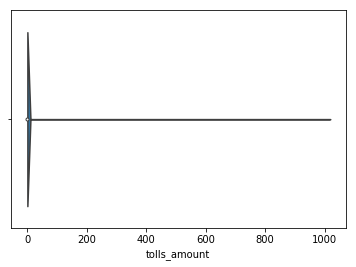

```python
sns.violinplot(x=df_taxi['tolls_amount'])
```

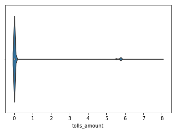

```python
sns.violinplot(x=df_taxi[(df_taxi['tolls_amount'] <= 8)]['tolls_amount'])
```

Total amount of all tolls paid in trip. Most of them are zero or next to zero.

**improvement_surcharge**

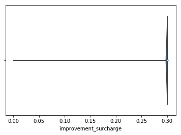

```python
sns.violinplot(x=df_taxi['improvement_surcharge'])
```

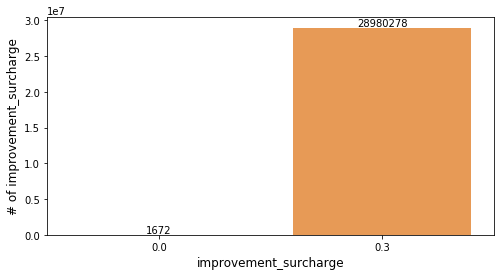

```python
x = df_taxi['improvement_surcharge'].value_counts()
x = x.sort_index()
styled_barplot(x, 'improvement_surcharge')
```

$0.30 improvement surcharge assessed trips at the flag drop. The improvement surcharge began being levied in 2015.

As expected, most trips have it because thay take place in 2017.

**total_amount**

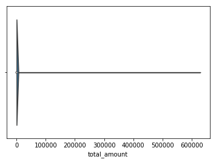

```python
sns.violinplot(x=df_taxi['total_amount'])
```

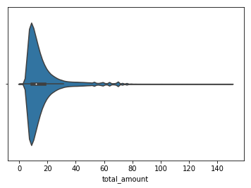

```python
sns.violinplot(x=df_taxi[(df_taxi['total_amount'] <= 150)]['total_amount'])
```

People don't spend much money in taxi. Most trips cost under $35

### Bivariate Analysis

```python
corr['tip_amount'] > 0.2
```

```
VendorID                 False
passenger_count          False
trip_distance             True
RatecodeID                True
store_and_fwd_flag       False
PULocationID             False
DOLocationID             False
payment_type             False
fare_amount              False
extra                    False
mta_tax                  False
tip_amount                True
tolls_amount              True
improvement_surcharge    False
total_amount             False
trip_duration            False
pickup_month             False
pickup_weekday           False
pickup_day               False
pickup_hour              False
dropoff_month            False
dropoff_weekday          False
dropoff_day              False
dropoff_hour             False
Name: tip_amount, dtype: bool
```

In the biviariate analysis I'd like to analyze variables that have some correlation with tip_amount

**trip_distance - tip_amount**

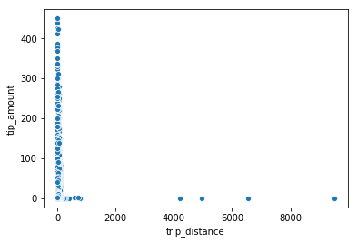

```python
sns.scatterplot(x="trip_distance", y="tip_amount", data=df_taxi)
```

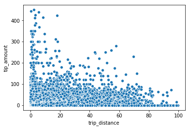

```python
sns.scatterplot(x="trip_distance", y="tip_amount", data=df_taxi[df_taxi['trip_distance'] < 100])
```

As expected, there are not a heavy correlation between the trip distance and the tip amount.

**tolls_amount - tip_amount**

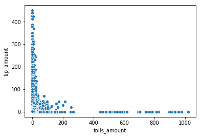

```python
sns.scatterplot(x="tolls_amount", y="tip_amount", data=df_taxi)
```

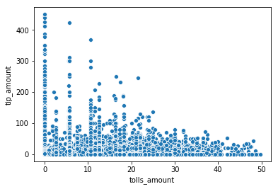

```python
sns.scatterplot(x="tolls_amount", y="tip_amount", data=df_taxi[df_taxi['tolls_amount'] < 50])
```

### Multivariate Analysis

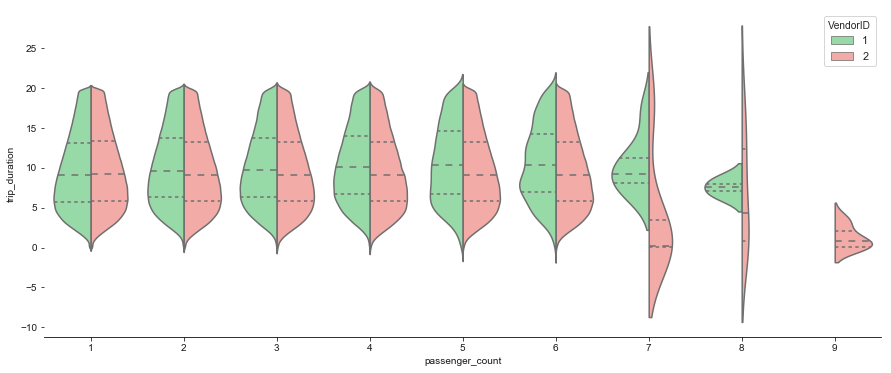

```python
plt.subplots(figsize=(15,6))
sns.set(style="whitegrid", palette="pastel", color_codes=True)
sns.violinplot(x="passenger_count", y="trip_duration", hue="VendorID", data=df_taxi[(df_taxi['trip_duration'] < 20)],
               split=True, inner="quart",palette={1: "g", 2: "r"})
sns.despine(left=True)
```

There are very less number of trips with passenger count 9 (only with vendor two)

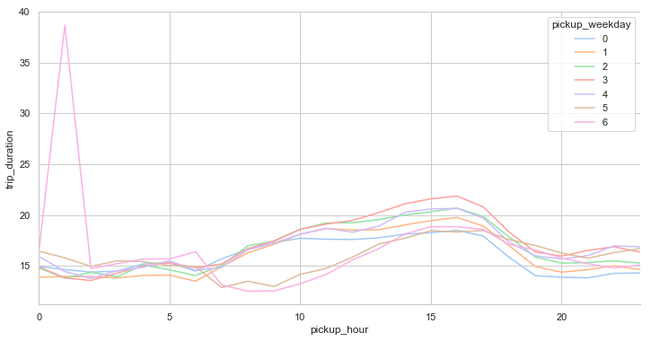

```python
df_hour_duration = pd.DataFrame(df_taxi.groupby(['pickup_weekday','pickup_hour'])['trip_duration'].mean())
df_hour_duration.reset_index(inplace = True)
df_hour_duration['unit'] = 1
plt.subplots(figsize=(12,6))
sns.tsplot(data=df_hour_duration, time="pickup_hour", unit = "unit", condition="pickup_weekday", value="trip_duration")
sns.despine(bottom = False)
```

During the first hours of the day on Sunday there is a peak. It could be interesting to investigate more about why. The other hours follow the same trend except on Sunday and Saturday from 7 to 13 where the trip duration falls.

## Model - Predicting tip amount

### Data Preparation

```python
df_taxi_creditcard = df_taxi[(df_taxi['payment_type'] == 1) & (df_taxi['tip_amount'] <= 15)]
```

```python
vendorid_dummies = pd.get_dummies(df_taxi_creditcard['VendorID'], prefix='vi', prefix_sep='_')
passenger_count_dummies = pd.get_dummies(df_taxi_creditcard['passenger_count'], prefix='pc', prefix_sep='_')
store_and_fwd_flag_dummies = pd.get_dummies(df_taxi_creditcard['store_and_fwd_flag'], prefix='sff', prefix_sep='_')
ratecodeid_dummies = pd.get_dummies(df_taxi_creditcard['RatecodeID'], prefix='rt', prefix_sep='_')
pickup_month_dummies = pd.get_dummies(df_taxi_creditcard['pickup_month'], prefix='pim', prefix_sep='_')
pickup_day_dummies = pd.get_dummies(df_taxi_creditcard['pickup_day'], prefix='pid', prefix_sep='_')
pickup_hour_dummies = pd.get_dummies(df_taxi_creditcard['pickup_hour'], prefix='pih', prefix_sep='_')
pickup_weekday_dummies = pd.get_dummies(df_taxi_creditcard['pickup_weekday'], prefix='piw', prefix_sep='_')

df_taxi_creditcard = pd.concat([df_taxi_creditcard, vendorid_dummies, passenger_count_dummies, store_and_fwd_flag_dummies, ratecodeid_dummies,
                    pickup_month_dummies, pickup_day_dummies, pickup_hour_dummies, pickup_weekday_dummies], axis=1)
```

```python
X = df_taxi_creditcard.drop(columns=['VendorID', 'tpep_pickup_datetime', 'tpep_dropoff_datetime', 'RatecodeID',
                  'passenger_count','store_and_fwd_flag', 'PULocationID', 'DOLocationID',
                  'payment_type', 'pickup_month','pickup_day','pickup_hour','pickup_weekday',
                  'dropoff_month','dropoff_day','dropoff_hour','dropoff_weekday', 'tip_amount'])
y = df_taxi_creditcard['tip_amount']
```

```python
X_train, X_test, y_train, y_test = train_test_split(X, y, test_size=0.33, random_state=42)
```

```python
dmatrix_train = xgb.DMatrix(X_train, label=y_train)
dmatrix_test = xgb.DMatrix(X_test, label=y_test)

watchlist = [(dmatrix_train, 'train'), (dmatrix_test, 'test')]
```

```python
xgb_pars = {'min_child_weight': 50, 'eta': 0.3, 'colsample_bytree': 0.3, 'max_depth': 10,
            'subsample': 0.8, 'lambda': 1., 'nthread': 4, 'booster' : 'gbtree', 'silent': 1,
            'eval_metric': 'rmse', 'objective': 'reg:linear'}

model = xgb.train(xgb_pars, dmatrix_train, 40, watchlist, early_stopping_rounds=10,
                  maximize=False, verbose_eval=10)

print('Best score %.5f' % model.best_score)
```

```
Multiple eval metrics have been passed: 'test-rmse' will be used for early stopping.

Will train until test-rmse hasn't improved in 10 rounds.
Best score 0.78655
```

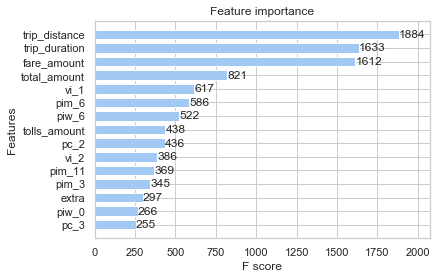

```python
xgb.plot_importance(model, max_num_features=15, height=0.7)
```

**Document your choice of model / algorithm, discussing why you chose it over alternatives** :

There are two main reasons why I have chosen XGBoost: the perfomance it offers and the execution speed.

XGBoost is really good with structured data on classification and regression predictive modeling problems. Moreover, this is a well-known algorithm with great support, so it's easy to understand and iterate over different approaches.

XGBoost implements the gradient boosting decision tree algorithm. The implementation of XGBoost give us quite advanced features for model tuning, computing environments and algorithm enhancement.

**Document how you assess your models performance**

The metric I used is RMSE. The root-mean-squared error is a measure of how well the model performed. It archive this by measuring difference betweeen predicted values and the actual values.

It is important to pay attention to train-rmse and test-rmse. The RMSE should be close for both the training data and the testing data. If RMSE for testing data is higher than the training data there are high possibilities that the model overfit.

**Discuss any limitations or caveats of the model which might be an issue in implementing it**

In order to improve the results I drop all observations with tip_amount higher than fifteen because most passengers don't give a tip higher than that value. So, when I tested without this limitation the model performed worse.

Another limitation is the hardware/time available:

- Playing with the features and the hyperparamters we can archive a better result.
- Also, a bigger dataset (maybe the entire year) would be great for the performance.

**Discuss how you might improve your model going forward**

If we delete the previous limitations we can improve the model's performance. Also, styding the feature importance and tuning them we can get better results. Moreover, we can test with other algorithms and compare the performance.

Also, we can binning the target ('tip_amount'). If the company doesn't need high precision we can transform this continuous variable to categorical in order to change the problem from regression to classification getting better results.

**Discuss how you might turn this model in to an API the company can use**

Depending on the complexity we want there are some options:

- Some cloud providers offer tools that are ready to solve this problem: AWS SageMaker, Azure ML... Each of them has limitations that it's important to study before take a decision.
- If we want a custom architecture we can use, for example, a EC2 instance (with auto-scaling depending on the use) controlled by a Lambda. We dockerize the train and the prediction and deploy them. For the API there are several options like using Flask (very easy and fast to develop) or more complex framework like Django. With the model trained and saved we have to request the predictions with the entry parameters.